# Componentes de una instalación industrial

Todo el contenido de esta guía tiene como base las Normaticas NAG201 y NAG200.

## 1. Normativa aplicable

En Argentina la NAG200 es la norma base para instalaciones domiciliarias y la NAG201 lo es para las instalaciones industriales.

La relación entre la NAG-200 y la NAG-201 es de complementariedad, donde la primera actúa como norma supletoria de la segunda en casos no previstos específicamente.

## 2. Diferencias entre una instalación industrial y domiciliaria

Las diferencias entre una instalación de gas industrial (NAG-201) y una domiciliaria (NAG-200) radican principalmente en la **escala de operación, los niveles de presión, la robustez de los materiales y la complejidad de los sistemas de seguridad**.

A continuación, se presenta un resumen de las principales diferencias según las fuentes:

- **Presión:** Las instalaciones domiciliarias se limita a presiones de hasta 28 mbar. Las industriales van de 19 hasta 3,95 bares.
- **Planta de Regulación y Medición:** La domiciliaria tiene un gabinete simple con un regulador y un medidor. La industrial cuenta con una **Planta de Regulación y Medición Primaria (PRMP)** más compleja.
- **Materiales y Métodos de Unión:** La domiciliaria permite una variedad de materiales como acero, cobre y sistemas de termofusión (acero-polietileno), con uniones roscadas, soldadas o mecánicas. En la industrial predominan las uniones soldadas.
- **Sistemas de Seguridad en los Equipos:** La domiciliaria usa artefactos que suelen usar dispositivos simples como la termocupla para el corte por falta de llama. La industrial (calderas, hornos) requieren sistemas automatizados complejos.
- **Protección y Entorno de la Instalación:** Las instalaciones industriales deben contar con protección catódica cuando corresponde, instalaciones eléctricas antiexplosivas y recintos construidos y especialmente señalizados.

## 3. Componentes de una instalación industrial

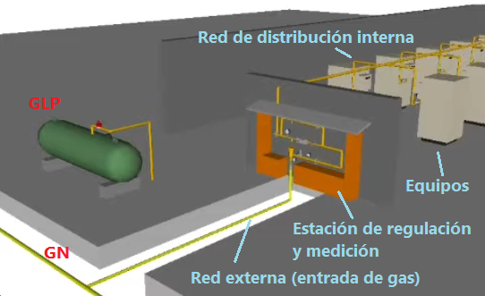

Fuente: Gustavo Serna P (canal youtube)

Los componentes esecíficos organizados por sistema son:

- **Planta de Regulación y Medición Primaria (PRMP):** Válvula de bloqueo general, filtros, reguladores de presión, válvulas de seguridad, medidor de gas, by-pass, precalentador (cuando corresponde) y juntas dieléctricas. ⌕
- **Plantas de Regulación Secundarias:** Reguladores, manómetros y válvulas de bloqueo para sectores con distinta presión.
- **Sistema de Conducción:** Cañerías de acero, uniones, soportes y válvulas de bloqueo de sector.
- **Sistemas de Seguridad:** Válvulas automáticas de cierre, detectores de llama, sistema de prebarrido y presóstatos.
- **Protección y Auxiliares:** Protección catódica, instalación eléctrica antiexplosiva (APE) y señalización reglamentaria.